# Telco

Anuar Baisynov, Martin Bech, Bawer Betasi, Thomas Matzen, Marius McIntosh

2022-10-30

# 1 Introduction

> Let’s load the dataset first…

```r
telco <- read.csv("Telco-Customer-Churn.csv")
```

## 1.1 Dataset Overview

> This dataset revolves itself around the **customer churn**. Inferably, the goal is thus to *use our progress in this course to predict the behavior of customers and thereby retain customers*, and perhaps provide preliminary findings for customer retention programs. As given away by the title, the data regards *“Telco”*, a hypothetical telecommunications company. Each row of the dataset is represented by a *customer*, and each column describes a *characteristic* of that customer and finally whether they have churned - or not. The dimensions of our dataset are: **7043, 21**, with **7043** rows and **21** columns. Some descriptive statistics follow.

```r
# Loading some data visualization packages...
suppressPackageStartupMessages(library(ggplot2))
suppressPackageStartupMessages(library(dplyr))
suppressPackageStartupMessages(library(gmodels))
suppressPackageStartupMessages(library(caret))
suppressPackageStartupMessages(library(C50))
suppressPackageStartupMessages(library(class))
suppressPackageStartupMessages(library(kernlab))
```

```r
# Rather than describing each column, have a look at the first few columns to
# understand the structure of the dataset.
head(telco)
```

```
##   customerID gender SeniorCitizen Partner Dependents tenure PhoneService
## 1 7590-VHVEG Female             0     Yes         No      1           No
## 2 5575-GNVDE   Male             0      No         No     34          Yes
## 3 3668-QPYBK   Male             0      No         No      2          Yes
## 4 7795-CFOCW   Male             0      No         No     45           No
## 5 9237-HQITU Female             0      No         No      2          Yes
## 6 9305-CDSKC Female             0      No         No      8          Yes
##      MultipleLines InternetService OnlineSecurity OnlineBackup DeviceProtection
## 1 No phone service             DSL             No          Yes               No
## 2               No             DSL            Yes           No              Yes
## 3               No             DSL            Yes          Yes               No
## 4 No phone service             DSL            Yes           No              Yes
## 5               No     Fiber optic             No           No               No
## 6              Yes     Fiber optic             No           No              Yes
##   TechSupport StreamingTV StreamingMovies       Contract PaperlessBilling
## 1          No          No              No Month-to-month              Yes
## 2          No          No              No       One year               No
## 3          No          No              No Month-to-month              Yes
## 4         Yes          No              No       One year               No
## 5          No          No              No Month-to-month              Yes
## 6          No         Yes             Yes Month-to-month              Yes
##               PaymentMethod MonthlyCharges TotalCharges Churn
## 1          Electronic check          29.85        29.85    No
## 2              Mailed check          56.95      1889.50    No
## 3              Mailed check          53.85       108.15   Yes
## 4 Bank transfer (automatic)          42.30      1840.75    No
## 5          Electronic check          70.70       151.65   Yes
## 6          Electronic check          99.65       820.50   Yes
```

```r
# Of course, we could run an str() here, but we haven't cleaned the dataset yet. This might lead to some
# confusion, but just beware that the "chr" variables will be turned into factors later on. Similarly,
# summary() is mostly pointless due to the "chr" columns.
str(telco)
```

```
## 'data.frame':    7043 obs. of  21 variables:
##  $ customerID      : chr  "7590-VHVEG" "5575-GNVDE" "3668-QPYBK" "7795-CFOCW" ...
##  $ gender          : chr  "Female" "Male" "Male" "Male" ...
##  $ SeniorCitizen   : int  0 0 0 0 0 0 0 0 0 0 ...
##  $ Partner         : chr  "Yes" "No" "No" "No" ...
##  $ Dependents      : chr  "No" "No" "No" "No" ...
##  $ tenure          : int  1 34 2 45 2 8 22 10 28 62 ...
##  $ PhoneService    : chr  "No" "Yes" "Yes" "No" ...
##  $ MultipleLines   : chr  "No phone service" "No" "No" "No phone service" ...
##  $ InternetService : chr  "DSL" "DSL" "DSL" "DSL" ...
##  $ OnlineSecurity  : chr  "No" "Yes" "Yes" "Yes" ...
##  $ OnlineBackup    : chr  "Yes" "No" "Yes" "No" ...
##  $ DeviceProtection: chr  "No" "Yes" "No" "Yes" ...
##  $ TechSupport     : chr  "No" "No" "No" "Yes" ...
##  $ StreamingTV     : chr  "No" "No" "No" "No" ...
##  $ StreamingMovies : chr  "No" "No" "No" "No" ...
##  $ Contract        : chr  "Month-to-month" "One year" "Month-to-month" "One year" ...
##  $ PaperlessBilling: chr  "Yes" "No" "Yes" "No" ...
##  $ PaymentMethod   : chr  "Electronic check" "Mailed check" "Mailed check" "Bank transfer (automatic)" ...
##  $ MonthlyCharges  : num  29.9 57 53.9 42.3 70.7 ...
##  $ TotalCharges    : num  29.9 1889.5 108.2 1840.8 151.7 ...
##  $ Churn           : chr  "No" "No" "Yes" "No" ...
```

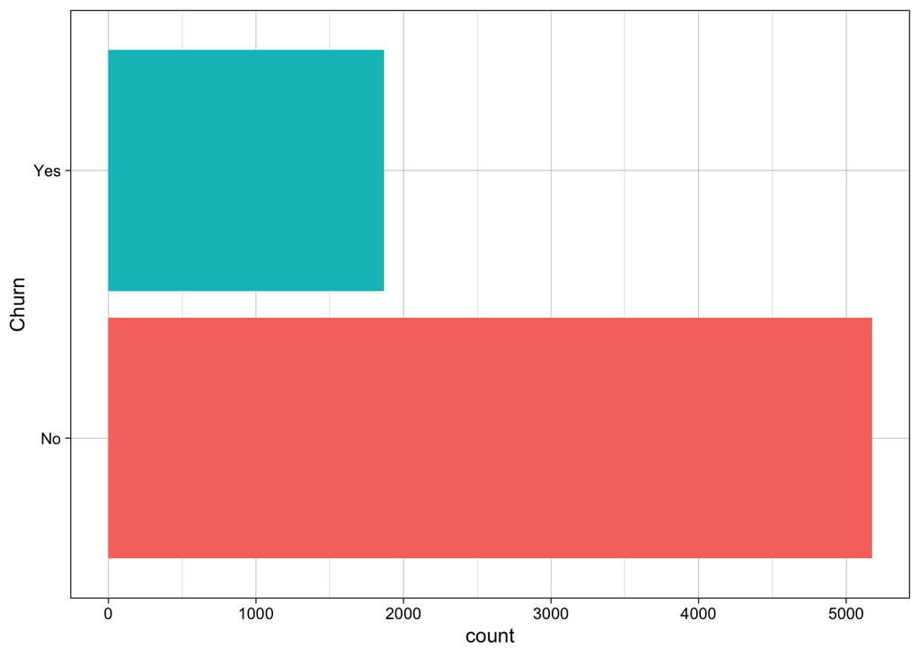

```r
# Let's look at the proportions of churn in our total set.
ggplot(data = telco, aes(x = Churn, fill = Churn)) +
  geom_bar() +
  theme_linedraw() +
  theme(legend.position = "none") +
  coord_flip()
```

```r
# We already see that the "yes" option occurs rather frequently,
# at more or less 1750 instances, whereas no occurs some 5100 times. However, we don't need to
# guesstimate here! Let's check the rows of yes and no for more specific data instead.
nrow(filter(telco, Churn == "Yes"))
```

```
## [1] 1869
```

```r
nrow(filter(telco, Churn == "No"))
```

```
## [1] 5174
```

```r
#Proportion of churn
nrow(filter(telco, Churn == "Yes"))/nrow(telco)
```

```
## [1] 0.2653699
```

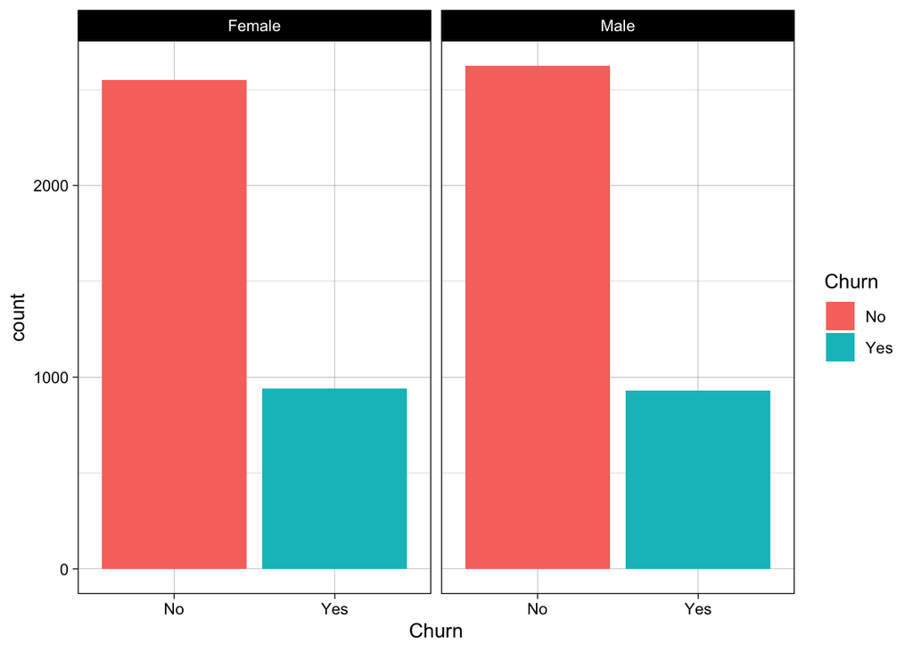

```r
# To be precise, we have 1869 customers churned out and 5174 retained.

# Next, we can already, as a de facto habit, look at whether the response variable churn differs per
# gender.
ggplot(data = telco, aes(x = Churn, fill = Churn)) +
  geom_bar() +
  theme_linedraw() +
  facet_wrap(~gender)
```

```r
# Without doing any other analysis, it appears to be the case that gender
# does not significantly affect churn. The two charts are near identical both in proportion and
# in size, indicating that there might be a near 50-50 split of gender across the churn count.
```

For the next descriptive section, let’s have a look at churn per some variables that - intuitively - could impact customer churn in a telecom firm.

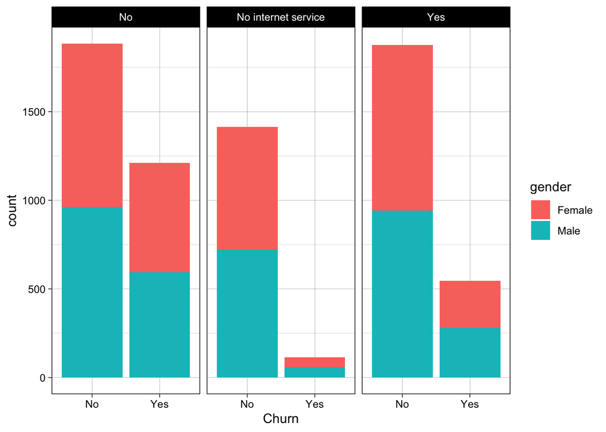

```r
# Let's start off with the DeviceProtection and how that impacts Churn.
# We can also look at the proportions of Gender here.
ggplot(data = telco, aes(x = Churn, fill = gender)) +
  geom_bar() +
  theme_linedraw() +
  facet_wrap(~DeviceProtection)
```

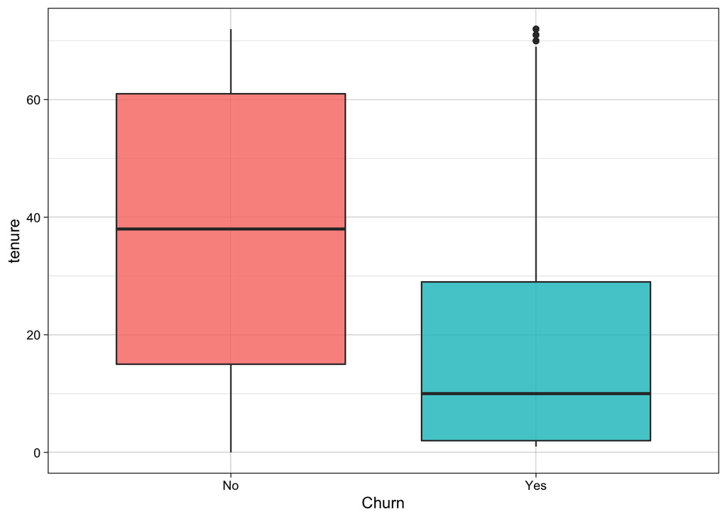

```r
# Interesting finding here: for the "No" option in DeviceProtection, the churn is relatively high
# compared to the other values in this category. Again, the male-female split appears to be almost
# exactly 50% in every kind of DeviceProtection.

# Next, how does the tenure affect churn? Perhaps customers who have stuck around for a while will
# continue to stick around and thus need less discounts, etc.?
ggplot(telco, aes(Churn, tenure, fill = Churn)) +
  geom_boxplot(alpha = 0.8) +
  theme_linedraw() +
  theme(legend.position = "none")
```

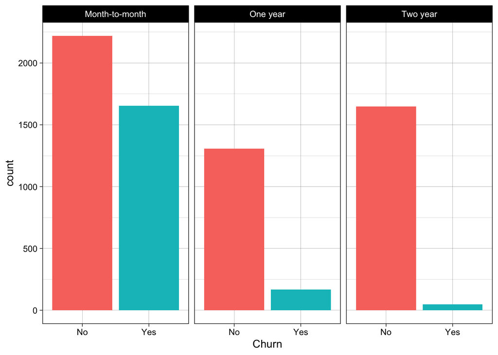

```r
# Interesting! The tenure appears to be higher for those who don't churn than those who will.
# We'll later explore whether this effect is significant. Perhaps, loyalty up to the present
# day is an indicator of future loyalty, after all.


# Up next, let's look at Churn by the Contract type. Perhaps a flexible month-to-month contract
# will result in more inclination to churn...
ggplot(telco, aes(Churn, fill = Churn)) +
  geom_bar() +
  theme_linedraw() +
  theme(legend.position = "none") +
  facet_wrap(~Contract)
```

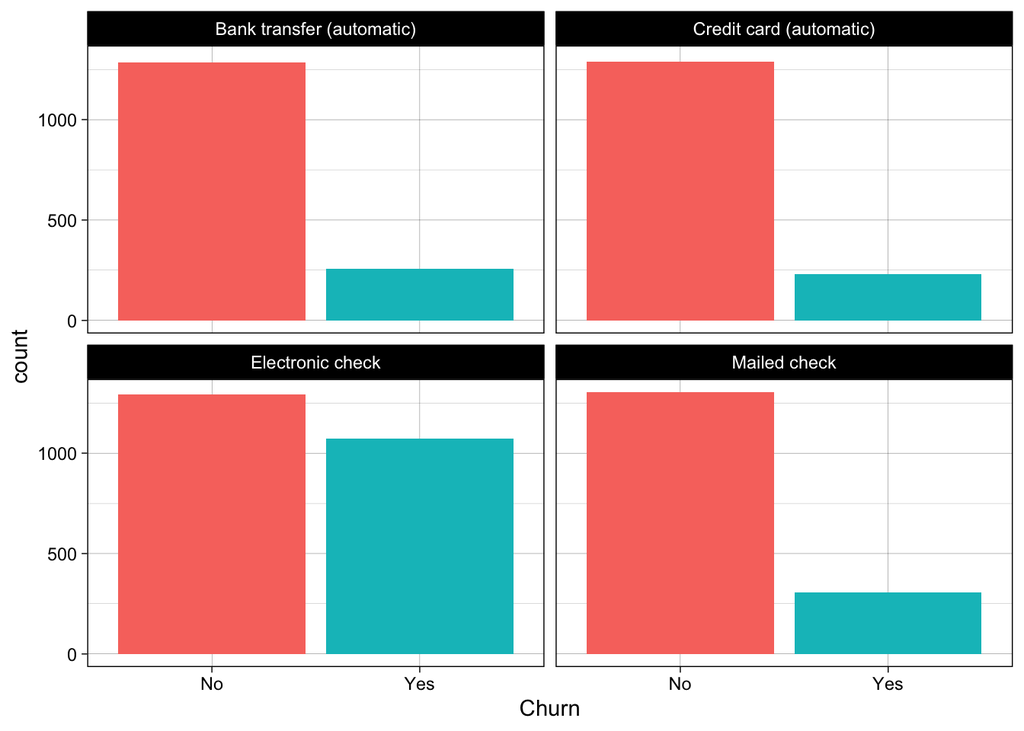

```r
# Our suspicion appears to be confirmed! The month-to-month contract has an extremely high churn rate
# relative to the other contract types... we'll later see whether this is significant through our
# regression model.

# And what about Churn per Payment Method used? Is flexibility here also a cause of more churn?
ggplot(telco, aes(Churn, fill = Churn)) +
  geom_bar() +
  theme_linedraw() +
  theme(legend.position = "none") +
  facet_wrap(~PaymentMethod)
```

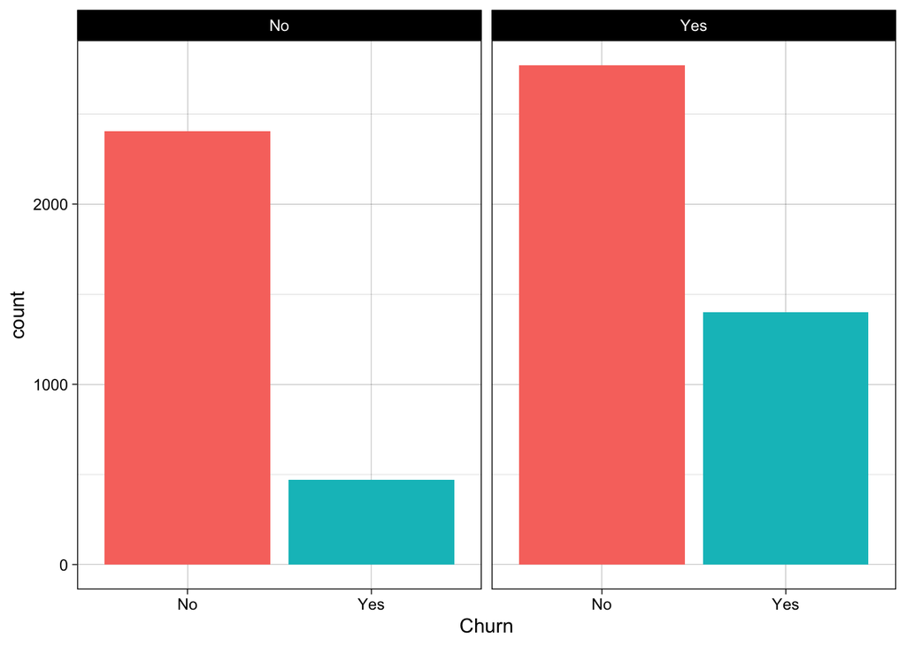

```r
# By simply looking at this, our eyes are set on the electronic check method. Although it has a
# similar "no" count as the other payment systems, the "yes" count is much, much higher! This is
# something we'd have to consider in our regression.

# What about Paperless Billing? Would the lack of a physical paper (that presumably needs to be signed)
# cause more churn?
ggplot(telco, aes(Churn, fill = Churn)) +
  geom_bar() +
  theme_linedraw() +
  theme(legend.position = "none") +
  facet_wrap(~PaperlessBilling)
```